# Final DA Exam — 36-401

Charles Gauthey

May 7, 2017

Load

```r
bikes = read.table("D:/Documents/CMU Courses/CMU Statistics Courses/Best 36-401/FinalDA3/final-71.txt")
attach(bikes)
source("D:/Documents/CMU Courses/CMU Statistics Courses/Best 36-401/FinalDA3/panelfxns(1).R")
library(plyr)
library(MASS)
```

Univariate EDA

```r
bikes.v2 = apply(bikes, 2, as.numeric)
apply(bikes.v2, 2, summary)
```

```
## $Registered
##    Min. 1st Qu.  Median    Mean 3rd Qu.    Max.
##     1.0    40.0   120.0   159.2   221.0   790.0
##
## $Date
##    Min. 1st Qu.  Median    Mean 3rd Qu.    Max.    NA's
##      NA      NA      NA     NaN      NA      NA     723
##
## $Year
##    Min. 1st Qu.  Median    Mean 3rd Qu.    Max.
##    2011    2011    2011    2011    2012    2012
##
## $Month
##    Min. 1st Qu.  Median    Mean 3rd Qu.    Max.
##   1.000   4.000   7.000   6.799  10.000  12.000
##
## $Day
##    Min. 1st Qu.  Median    Mean 3rd Qu.    Max.
##   0.000   1.000   3.000   2.996   5.000   6.000
##
## $Hour
##    Min. 1st Qu.  Median    Mean 3rd Qu.    Max.
##     0.0     6.0    11.0    11.6    17.5    23.0
##
## $Holiday
##    Min. 1st Qu.  Median    Mean 3rd Qu.    Max.
## 0.00000 0.00000 0.00000 0.03734 0.00000 1.00000
##
## $WorkDay
##    Min. 1st Qu.  Median    Mean 3rd Qu.    Max.
##  0.0000  0.0000  1.0000  0.6985  1.0000  1.0000
##
## $Weather
##    Min. 1st Qu.  Median    Mean 3rd Qu.    Max.
##   1.000   1.000   1.000   1.429   2.000   3.000
##
## $Temp
##    Min. 1st Qu.  Median    Mean 3rd Qu.    Max.
##  0.0400  0.3400  0.5200  0.5102  0.6600  0.9600
##
## $TempFeel
##    Min. 1st Qu.  Median    Mean 3rd Qu.    Max.
##  0.0303  0.3333  0.5000  0.4879  0.6212  0.9848
##
## $Humidity
##    Min. 1st Qu.  Median    Mean 3rd Qu.    Max.
##  0.0000  0.5000  0.6500  0.6361  0.7800  1.0000
##
## $Windspeed
##    Min. 1st Qu.  Median    Mean 3rd Qu.    Max.
##  0.0000  0.1045  0.1940  0.1933  0.2836  0.8507
##
## $Casual
##    Min. 1st Qu.  Median    Mean 3rd Qu.    Max.
##    0.00    4.00   18.00   34.52   47.00  291.00
```

```r
apply(bikes.v2, 2, sd)
```

```
##  Registered        Date        Year       Month         Day        Hour
## 160.0606363          NA   0.4992878   3.4007331   1.9745568   6.8400681
##     Holiday     WorkDay     Weather        Temp    TempFeel    Humidity
##   0.1897356   0.4592363   0.6521662   0.1977249   0.1780542   0.1823290
##   Windspeed      Casual
##   0.1194611  45.6896457
```

```r
apply(bikes, 2, table)
```

[output not shown]

[output cut: 238 more lines]

[output not shown]

```r
nrow(bikes)
```

```
## [1] 723
```

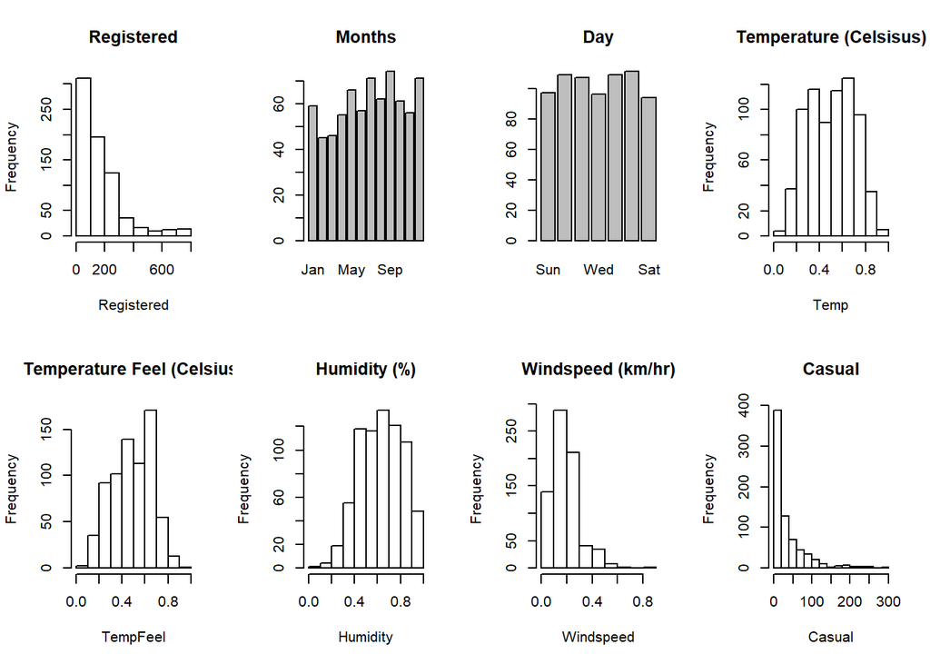

```r
par(mfrow = c(2,4))
hist(Registered, main = "Registered")
barplot(table(Month),names.arg=c("Jan","Feb","Mar","Apr","May","Jun","Jul","Aug","Sep","Oct","Nov","Dec"), main = "Months")
barplot(table(Day),names.arg=c("Sun","Mon","Tue","Wed","Thu","Fri","Sat"), main = "Day")
hist(Temp, main = "Temperature (Celsisus)")
hist(TempFeel, main = "Temperature Feel (Celsius)")
hist(Humidity, main = "Humidity (%)")
hist(Windspeed, main = "Windspeed (km/hr)")
hist(Casual, main = "Casual")
```

Univariate EDA to-do: Find summary data on Excel and post those. Post the histograms and describe the distributions.

Multivariate EDA

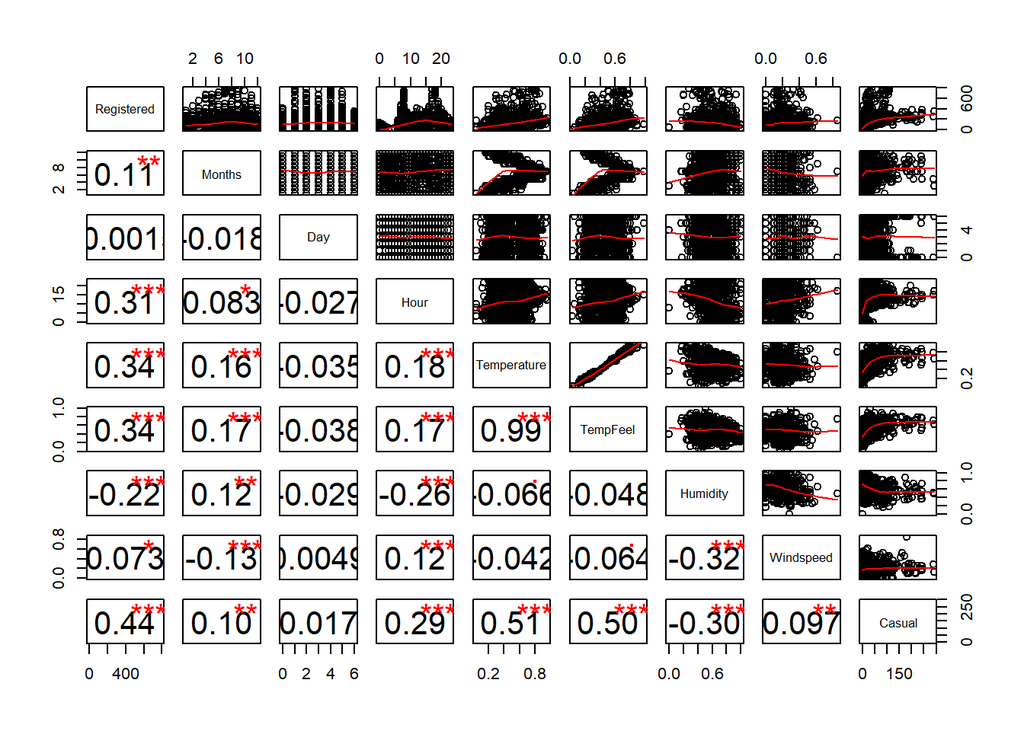

```r
#Continous EDA
par(mfrow = c(1,1))
cont.vars<-cbind(Registered,Month,Day,Hour, Temp,TempFeel,Humidity, Windspeed,Casual)
colnames(cont.vars)<-c("Registered","Months","Day","Hour","Temperature","TempFeel","Humidity","Windspeed","Casual")
pairs(cont.vars,upper.panel=panel.smooth,lower.panel=panel.cor)
```

```r
#Categorical EDA
mean(Registered[Year == 2011]);sd(Registered[Year == 2011])
```

```
## [1] 120.0312
```

```
## [1] 100.6841
```

```r
mean(Registered[Year == 2012]);sd(Registered[Year == 2012])
```

```
## [1] 203.7515
```

```
## [1] 198.9807
```

```r
mean(Registered[Holiday == 0]);sd(Registered[Holiday == 0])
```

```
## [1] 161.0287
```

```
## [1] 162.087
```

```r
mean(Registered[Holiday == 1]);sd(Registered[Holiday == 1])
```

```
## [1] 111.2593
```

```
## [1] 81.72449
```

```r
mean(Registered[WorkDay == 0]);sd(Registered[WorkDay == 0])
```

```
## [1] 118.3073
```

```
## [1] 95.51433
```

```r
mean(Registered[WorkDay == 1]);sd(Registered[WorkDay== 1])
```

```
## [1] 176.8099
```

```
## [1] 178.154
```

```r
mean(Registered[Weather == 1]);sd(Registered[Weather== 1])
```

```
## [1] 172.4393
```

```
## [1] 173.6512
```

```r
mean(Registered[Weather == 2]);sd(Registered[Weather == 2])
```

```
## [1] 141.3333
```

```
## [1] 130.7061
```

```r
mean(Registered[Weather == 3]);sd(Registered[Weather == 3])
```

```
## [1] 110.9846
```

```
## [1] 109.188
```

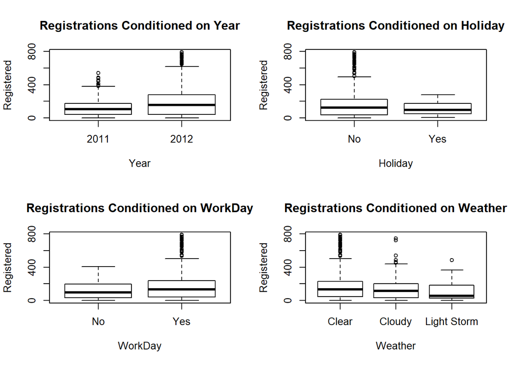

```r
par(mfrow = c(2,2))
boxplot(Registered~Year,names=c(2011,2012),main = "Registrations Conditioned on Year")
boxplot(Registered~Holiday,names=c("No","Yes"),main = "Registrations Conditioned on Holiday")
boxplot(Registered~WorkDay,names=c("No","Yes"),main = "Registrations Conditioned on WorkDay")
boxplot(Registered~Weather,names=c("Clear","Cloudy","Light Storm"),main = "Registrations Conditioned on Weather")
```

Multivariate EDA to-do: Post pair plots, boxplots. On Pairs, note the 3-stars ones. Boxplots recieve support from Excel sheet

Initial Modeling

```r
#Model 1 Basic: Official Categoricals
mod1.1 = lm(Registered~Year+Month+Day+Hour+Holiday+WorkDay+Weather+Temp+TempFeel+Humidity+Windspeed+Casual)

summary(mod1.1)
```

```
##
## Call:
## lm(formula = Registered ~ Year + Month + Day + Hour + Holiday +
##     WorkDay + Weather + Temp + TempFeel + Humidity + Windspeed +
##     Casual)
##
## Residuals:
##     Min      1Q  Median      3Q     Max
## -359.91  -79.64  -24.08   37.42  539.79
##
## Coefficients:
##               Estimate Std. Error t value Pr(>|t|)
## (Intercept) -1.378e+05  1.942e+04  -7.095 3.13e-12 ***
## Year         6.850e+01  9.655e+00   7.094 3.16e-12 ***
## Month        3.740e+00  1.449e+00   2.581   0.0100 *
## Day         -7.916e-01  2.422e+00  -0.327   0.7439
## Hour         3.826e+00  7.513e-01   5.093 4.52e-07 ***
## Holiday     -1.807e+01  2.647e+01  -0.683   0.4949
## WorkDay      9.960e+01  1.186e+01   8.401 2.40e-16 ***
## Weather     -1.599e+01  8.187e+00  -1.953   0.0512 .
## Temp        -3.589e+01  2.031e+02  -0.177   0.8597
## TempFeel     1.034e+02  2.265e+02   0.457   0.6481
## Humidity    -3.035e+01  3.301e+01  -0.919   0.3582
## Windspeed    4.497e+01  4.308e+01   1.044   0.2970
## Casual       1.398e+00  1.414e-01   9.888  < 2e-16 ***
## ---
## Signif. codes:  0 '***' 0.001 '**' 0.01 '*' 0.05 '.' 0.1 ' ' 1
##
## Residual standard error: 127.1 on 710 degrees of freedom
## Multiple R-squared:  0.3799, Adjusted R-squared:  0.3694
## F-statistic: 36.25 on 12 and 710 DF,  p-value: < 2.2e-16
```

```r
mod1.2 = lm(Registered~as.factor(Year)+as.factor(Month)+Day+Hour+Holiday+WorkDay+Weather+Temp+TempFeel+Humidity+Windspeed+Casual)
summary(mod1.2)
```

```
##
## Call:
## lm(formula = Registered ~ as.factor(Year) + as.factor(Month) +
##     Day + Hour + Holiday + WorkDay + Weather + Temp + TempFeel +
##     Humidity + Windspeed + Casual)
##
## Residuals:
##     Min      1Q  Median      3Q     Max
## -365.01  -77.78  -24.38   35.72  532.84
##
## Coefficients:
##                     Estimate Std. Error t value Pr(>|t|)
## (Intercept)         -44.0077    34.6449  -1.270   0.2044
## as.factor(Year)2012  69.4091     9.7202   7.141 2.33e-12 ***
## as.factor(Month)2    10.7280    25.7233   0.417   0.6768
## as.factor(Month)3    25.0870    25.8828   0.969   0.3328
## as.factor(Month)4    49.4519    27.0751   1.826   0.0682 .
## as.factor(Month)5    27.1864    30.8201   0.882   0.3780
## as.factor(Month)6    45.1427    34.4797   1.309   0.1909
## as.factor(Month)7    66.3999    36.4420   1.822   0.0689 .
## as.factor(Month)8    45.1651    35.2343   1.282   0.2003
## as.factor(Month)9    78.2048    30.9522   2.527   0.0117 *
## as.factor(Month)10   65.1356    27.6480   2.356   0.0188 *
## as.factor(Month)11   61.1059    25.1406   2.431   0.0153 *
## as.factor(Month)12   30.3985    23.0131   1.321   0.1870
## Day                  -0.8659     2.4405  -0.355   0.7229
## Hour                  4.0200     0.7751   5.186 2.81e-07 ***
## Holiday             -17.9057    26.7998  -0.668   0.5043
## WorkDay             100.2996    11.9549   8.390 2.68e-16 ***
## Weather             -16.1299     8.3306  -1.936   0.0532 .
## Temp                -94.1394   223.2938  -0.422   0.6735
## TempFeel            108.5241   233.9823   0.464   0.6429
## Humidity            -39.7961    34.3639  -1.158   0.2472
## Windspeed            46.4634    43.8779   1.059   0.2900
## Casual                1.3933     0.1441   9.666  < 2e-16 ***
## ---
## Signif. codes:  0 '***' 0.001 '**' 0.01 '*' 0.05 '.' 0.1 ' ' 1
##
## Residual standard error: 127.2 on 700 degrees of freedom
## Multiple R-squared:  0.3879, Adjusted R-squared:  0.3687
## F-statistic: 20.16 on 22 and 700 DF,  p-value: < 2.2e-16
```

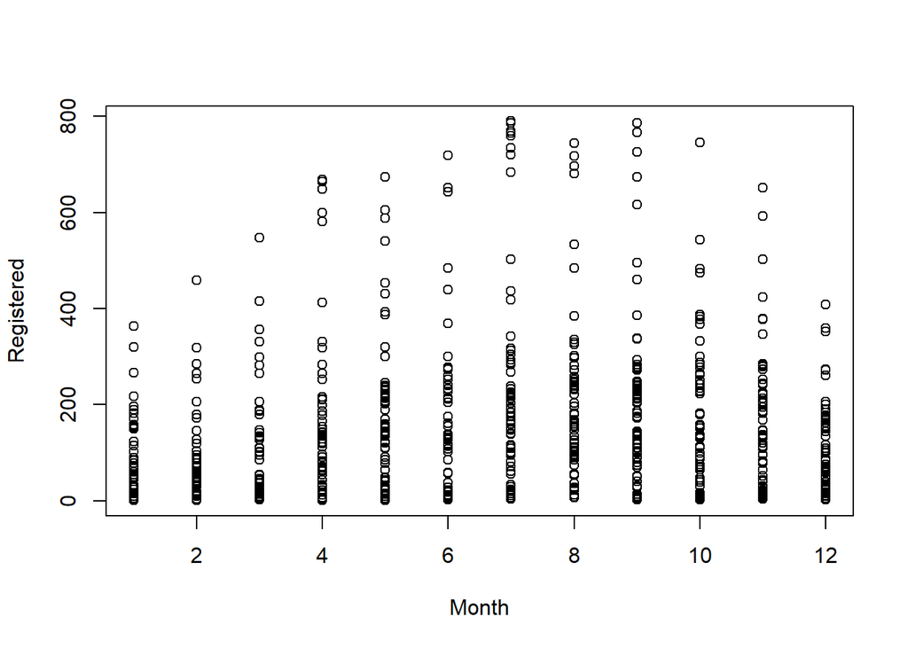

```r
Winter = ifelse(Month == 1 | Month == 2 | Month == 12, 1, 0)
Spring = ifelse(Month == 3 | Month == 4 | Month == 5, 1, 0)
Summer = ifelse(Month == 6 | Month == 7 | Month == 8, 1, 0)
Fall = ifelse(Month == 9 | Month == 10 | Month == 11, 1, 0)

#Analyzing splitting Months into seasons
plot(Month, Registered)
```

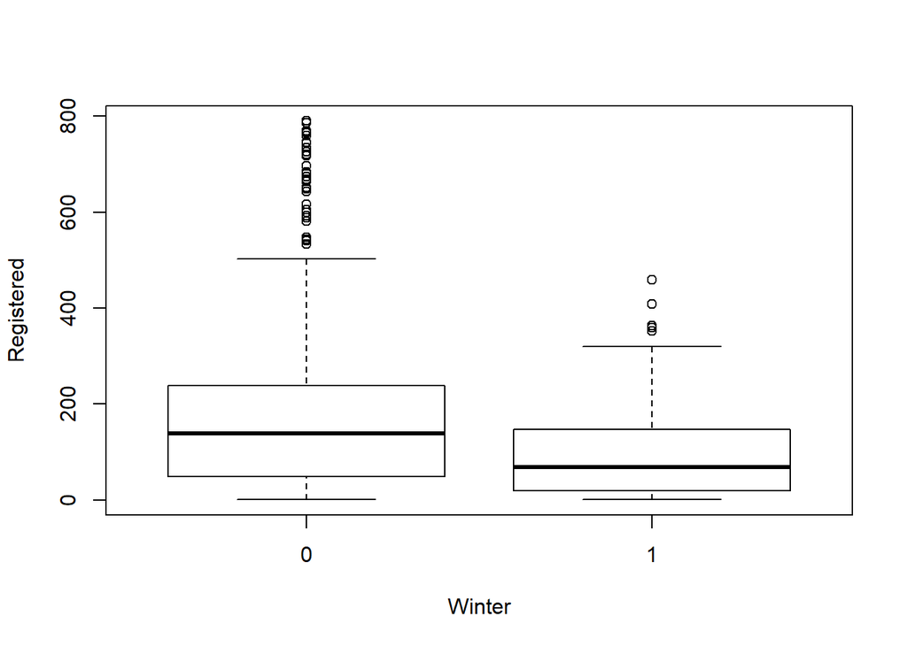

```r
boxplot(Registered~Winter)
```

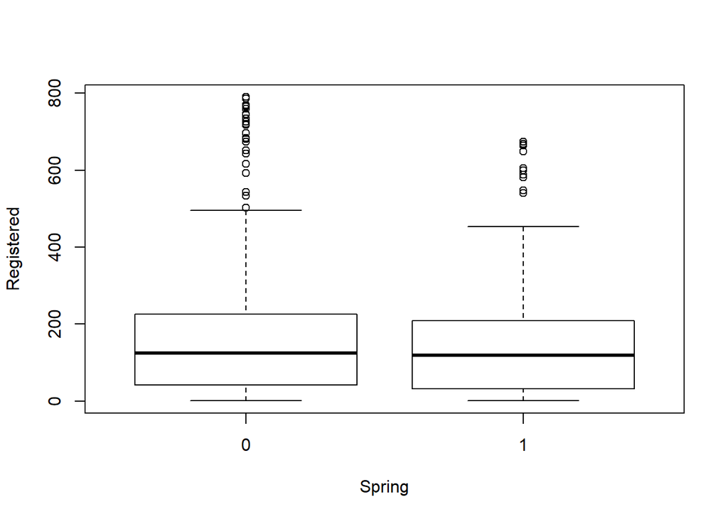

```r
boxplot(Registered~Spring)
```

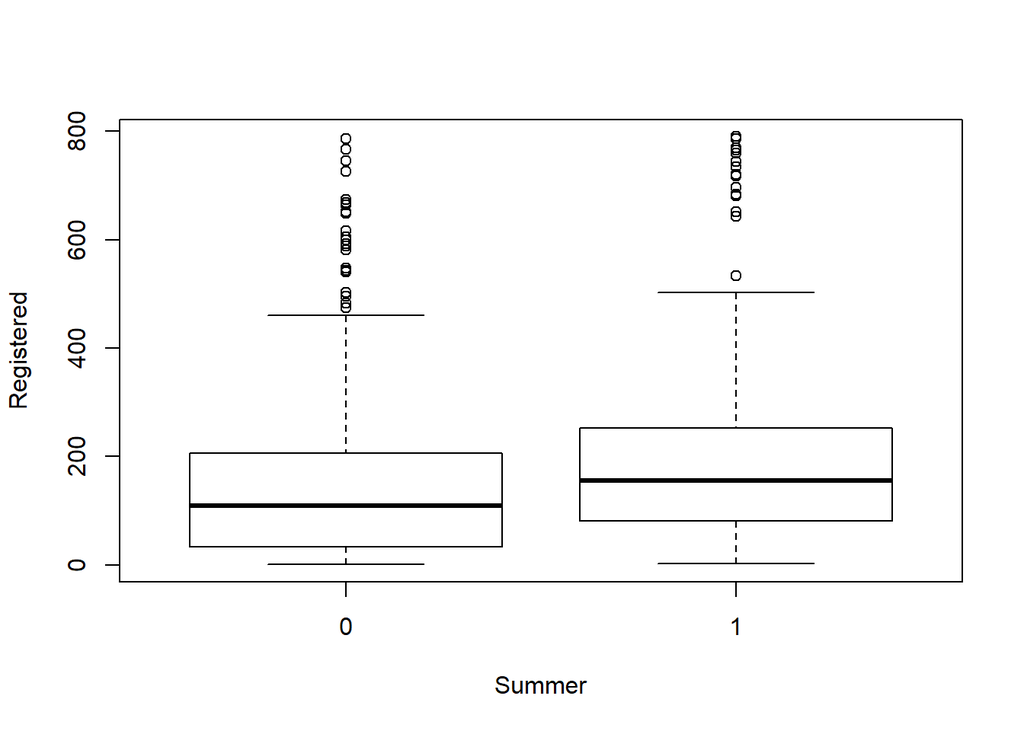

```r
boxplot(Registered~Summer)
```

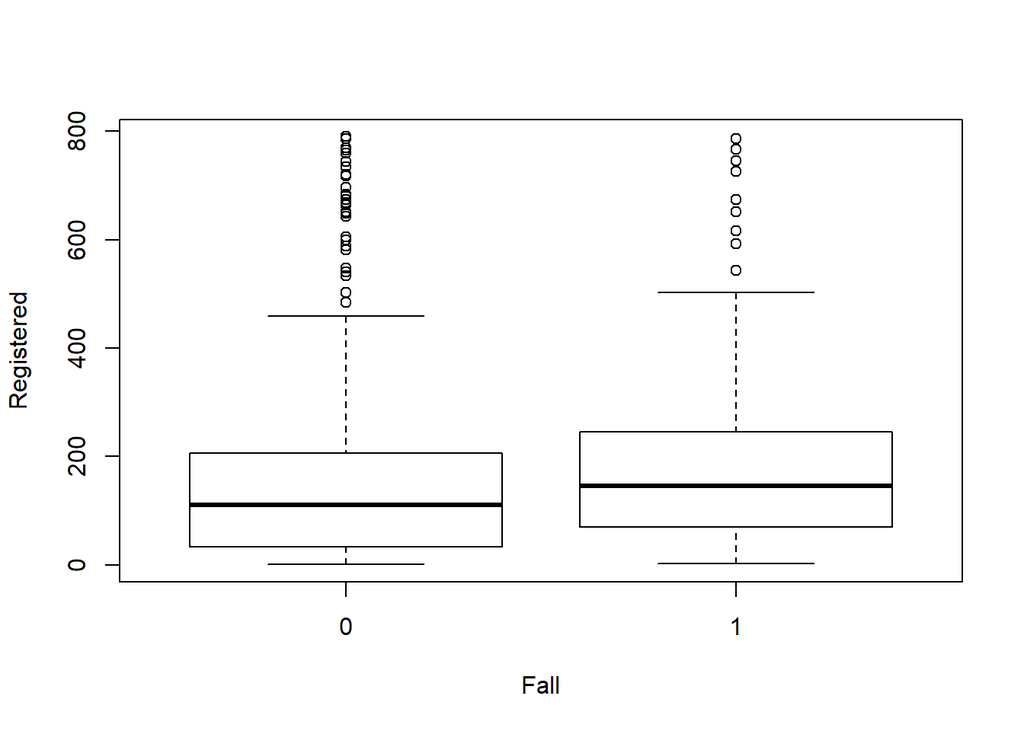

```r
boxplot(Registered~Fall)
```

```r
c(mean(Temp[Month==1]),mean(Temp[Month==2]),mean(Temp[Month==3]),mean(Temp[Month==4]),mean(Temp[Month==5]),mean(Temp[Month==6]),mean(Temp[Month==7]),mean(Temp[Month==8]),mean(Temp[Month==9]),mean(Temp[Month==10]),mean(Temp[Month==11]),mean(Temp[Month==12]) )
```

```
##  [1] 0.2393220 0.3182222 0.3547826 0.4683636 0.6169697 0.6856140 0.7661972
##  [8] 0.7190323 0.6191892 0.5006557 0.3800000 0.3087324
```

```r
order(c(mean(Temp[Month==1]),mean(Temp[Month==2]),mean(Temp[Month==3]),mean(Temp[Month==4]),mean(Temp[Month==5]),mean(Temp[Month==6]),mean(Temp[Month==7]),mean(Temp[Month==8]),mean(Temp[Month==9]),mean(Temp[Month==10]),mean(Temp[Month==11]),mean(Temp[Month==12]) ))
```

```
##  [1]  1 12  2  3 11  4 10  5  9  6  8  7
```

```r
mod1.3 = lm(Registered~as.factor(Year)+Spring+Summer+Fall+Day+Hour+Holiday+WorkDay+Weather+Temp+TempFeel+Humidity+Windspeed+Casual+Weather*Holiday+WorkDay*Hour)
summary(mod1.3)
```

```
##
## Call:
## lm(formula = Registered ~ as.factor(Year) + Spring + Summer +
##     Fall + Day + Hour + Holiday + WorkDay + Weather + Temp +
##     TempFeel + Humidity + Windspeed + Casual + Weather * Holiday +
##     WorkDay * Hour)
##
## Residuals:
##     Min      1Q  Median      3Q     Max
## -377.82  -77.59  -25.40   33.57  532.34
##
## Coefficients:
##                     Estimate Std. Error t value Pr(>|t|)
## (Intercept)         -13.1002    33.4324  -0.392  0.69529
## as.factor(Year)2012  67.9815     9.6502   7.045 4.43e-12 ***
## Spring               13.1381    16.2601   0.808  0.41936
## Summer               26.6839    22.5074   1.186  0.23620
## Fall                 46.4129    16.2864   2.850  0.00450 **
## Day                  -0.5913     2.4236  -0.244  0.80732
## Hour                  1.7228     1.3158   1.309  0.19087
## Holiday               2.6884    65.9576   0.041  0.96750
## WorkDay              60.7182    20.8749   2.909  0.00374 **
## Weather             -15.9980     8.2319  -1.943  0.05236 .
## Temp                -56.3772   209.0989  -0.270  0.78753
## TempFeel             87.6678   227.2312   0.386  0.69975
## Humidity            -28.8299    33.2335  -0.867  0.38597
## Windspeed            46.3135    43.2264   1.071  0.28435
## Casual                1.4289     0.1446   9.885  < 2e-16 ***
## Holiday:Weather     -17.8201    48.0407  -0.371  0.71079
## Hour:WorkDay          3.3596     1.5273   2.200  0.02815 *
## ---
## Signif. codes:  0 '***' 0.001 '**' 0.01 '*' 0.05 '.' 0.1 ' ' 1
##
## Residual standard error: 126.6 on 706 degrees of freedom
## Multiple R-squared:  0.3881, Adjusted R-squared:  0.3743
## F-statistic: 27.99 on 16 and 706 DF,  p-value: < 2.2e-16
```

```r
'
month.colder = ifelse(Month == 1 | Month == 2 | Month == 3 | Month == 4 | Month == 11| Month == 12, 1, 0)
month.warmer = ifelse(Month == 5 | Month == 6 | Month == 7 | Month == 8 | Month == 9| Month == 10, 1, 0)
mod1.4  = lm(Registered~as.factor(Year)+month.warmer+Day+Hour+Holiday+WorkDay+Weather+Temp+TempFeel+Humidity+Windspeed+Casual+Weather*Holiday+WorkDay*Hour)
summary(mod1.4)'
```

```
## [1] "\nmonth.colder = ifelse(Month == 1 | Month == 2 | Month == 3 | Month == 4 | Month == 11| Month == 12, 1, 0)\nmonth.warmer = ifelse(Month == 5 | Month == 6 | Month == 7 | Month == 8 | Month == 9| Month == 10, 1, 0)\nmod1.4  = lm(Registered~as.factor(Year)+month.warmer+Day+Hour+Holiday+WorkDay…
```

```r
'mod1.5 = lm(Registered~as.factor(Year)+as.factor(Month)+as.factor(Day)+Hour+Holiday+WorkDay+Weather+Temp+TempFeel+Humidity+Windspeed+Casual)
summary(mod1.5)
mod1.6 = lm(Registered~as.factor(Year)+as.factor(Month)+as.factor(Day)+Hour+Holiday+Weather+Temp+TempFeel+Humidity+Windspeed+Casual)
summary(mod1.6)'
```

```
## [1] "mod1.5 = lm(Registered~as.factor(Year)+as.factor(Month)+as.factor(Day)+Hour+Holiday+WorkDay+Weather+Temp+TempFeel+Humidity+Windspeed+Casual)\nsummary(mod1.5)\nmod1.6 = lm(Registered~as.factor(Year)+as.factor(Month)+as.factor(Day)+Hour+Holiday+Weather+Temp+TempFeel+Humidity+Windspeed+Casual)\…
```

```r
mod1.7 = lm(Registered~as.factor(Year)+Spring+Summer+Fall+Hour+Holiday+as.factor(WorkDay)+Weather+Temp+TempFeel+Humidity+Windspeed+Casual)
summary(mod1.7)
```

```
##
## Call:
## lm(formula = Registered ~ as.factor(Year) + Spring + Summer +
##     Fall + Hour + Holiday + as.factor(WorkDay) + Weather + Temp +
##     TempFeel + Humidity + Windspeed + Casual)
##
## Residuals:
##     Min      1Q  Median      3Q     Max
## -367.77  -75.87  -25.98   34.18  528.65
##
## Coefficients:
##                     Estimate Std. Error t value Pr(>|t|)
## (Intercept)         -40.4307    30.1481  -1.341  0.18033
## as.factor(Year)2012  68.9035     9.6387   7.149 2.19e-12 ***
## Spring               14.4547    16.2275   0.891  0.37336
## Summer               28.6371    22.4641   1.275  0.20280
## Fall                 48.6749    16.2707   2.992  0.00287 **
## Hour                  4.1099     0.7559   5.437 7.47e-08 ***
## Holiday             -15.2200    26.3263  -0.578  0.56336
## as.factor(WorkDay)1  98.2945    11.8320   8.308 4.96e-16 ***
## Weather             -16.4164     8.1769  -2.008  0.04506 *
## Temp                -72.5215   209.1434  -0.347  0.72888
## TempFeel            111.1149   227.1614   0.489  0.62489
## Humidity            -34.6750    33.1511  -1.046  0.29593
## Windspeed            45.6293    43.2768   1.054  0.29208
## Casual                1.3729     0.1425   9.634  < 2e-16 ***
## ---
## Signif. codes:  0 '***' 0.001 '**' 0.01 '*' 0.05 '.' 0.1 ' ' 1
##
## Residual standard error: 126.8 on 709 degrees of freedom
## Multiple R-squared:  0.3838, Adjusted R-squared:  0.3725
## F-statistic: 33.96 on 13 and 709 DF,  p-value: < 2.2e-16
```

```r
OffHours.Night = ifelse(Hour == 0 | Hour == 1  | Hour == 2 |Hour == 3 | Hour == 4 |Hour == 5|Hour == 6|Hour == 21|Hour == 22|Hour == 23, 1, 0)
RushHour.Day = ifelse(Hour == 7 | Hour == 8  | Hour == 9 , 1, 0)
OffHours.Day = ifelse(Hour == 10 | Hour == 11 | Hour == 12 |Hour == 13 | Hour == 14 |Hour == 15, 1, 0)
RushHour.Night = ifelse(Hour == 16 | Hour == 17  | Hour == 18|Hour == 19  | Hour == 20 , 1, 0)


'mod1.8 = lm(Registered~as.factor(Year)+Spring+Summer+Fall+as.factor(Hour)+as.factor(Holiday)+as.factor(WorkDay)+Weather+Temp+TempFeel+Humidity+Windspeed+Casual)
summary(mod1.8)'
```

```
## [1] "mod1.8 = lm(Registered~as.factor(Year)+Spring+Summer+Fall+as.factor(Hour)+as.factor(Holiday)+as.factor(WorkDay)+Weather+Temp+TempFeel+Humidity+Windspeed+Casual)\nsummary(mod1.8)"
```

```r
mod1.9 = lm(Registered~as.factor(Year)+Spring+Summer+Fall+RushHour.Day+OffHours.Day+RushHour.Night+as.factor(Holiday)+as.factor(WorkDay)+Weather+Temp+TempFeel+Humidity+Windspeed+Casual)
summary(mod1.9)
```

```
##
## Call:
## lm(formula = Registered ~ as.factor(Year) + Spring + Summer +
##     Fall + RushHour.Day + OffHours.Day + RushHour.Night + as.factor(Holiday) +
##     as.factor(WorkDay) + Weather + Temp + TempFeel + Humidity +
##     Windspeed + Casual)
##
## Residuals:
##     Min      1Q  Median      3Q     Max
## -278.84  -66.12  -11.72   46.36  399.30
##
## Coefficients:
##                     Estimate Std. Error t value Pr(>|t|)
## (Intercept)         -53.8169    23.6551  -2.275 0.023201 *
## as.factor(Year)2012  71.2618     7.8569   9.070  < 2e-16 ***
## Spring                6.3472    13.2054   0.481 0.630914
## Summer               18.6062    18.2244   1.021 0.307629
## Fall                 46.2949    13.1323   3.525 0.000450 ***
## RushHour.Day        185.3750    11.4628  16.172  < 2e-16 ***
## OffHours.Day         34.2283    12.5981   2.717 0.006750 **
## RushHour.Night      178.9672    12.3548  14.486  < 2e-16 ***
## as.factor(Holiday)1 -19.8602    21.1036  -0.941 0.346985
## as.factor(WorkDay)1  92.5729     9.5915   9.652  < 2e-16 ***
## Weather             -22.3523     6.7295  -3.322 0.000941 ***
## Temp                -50.9359   167.7244  -0.304 0.761455
## TempFeel            132.3692   182.4149   0.726 0.468294
## Humidity            -35.5396    27.7734  -1.280 0.201095
## Windspeed             8.1053    34.8735   0.232 0.816278
## Casual                1.1570     0.1238   9.344  < 2e-16 ***
## ---
## Signif. codes:  0 '***' 0.001 '**' 0.01 '*' 0.05 '.' 0.1 ' ' 1
##
## Residual standard error: 101.7 on 707 degrees of freedom
## Multiple R-squared:  0.6043, Adjusted R-squared:  0.5959
## F-statistic: 71.98 on 15 and 707 DF,  p-value: < 2.2e-16
```

```r
'mod1.10 = lm(Registered~as.factor(Year)+as.factor(Month)+as.factor(Hour)+as.factor(Holiday)+as.factor(WorkDay)+as.factor(Weather)+Temp+TempFeel+Humidity+Windspeed+Casual)
summary(mod1.10)'
```

```
## [1] "mod1.10 = lm(Registered~as.factor(Year)+as.factor(Month)+as.factor(Hour)+as.factor(Holiday)+as.factor(WorkDay)+as.factor(Weather)+Temp+TempFeel+Humidity+Windspeed+Casual)\nsummary(mod1.10)"
```

First analyze weather Month is ordered or categorical. Noticed a bell-curve, non-linear relationship in our Multivariate EDA. Use as factor. Slightly less stable, but notice the average issue. Could split into seasons (stability), but concept of seasons may be arbitrary. If based on temperatures, below above 50 percentile better. However, takes away from wide range of averages. Sacrifice minimal stability to turn into factors. Conclusion, don’t make it ordered (normal categorical).

Day is similar to Month. However, we realize WorkDay variable kind of does a similar function. Causes NA with WorkDay. Issue is factor Day and WorkDay looks at the same thing. WorkDay is more stable. Not much different in information and average coefficients. Conclusion, use WorkDay and take out Day.

Hour factor. Huge range. Big jump in adj- R^2. Categorize, not ordered. Lot of variables, but nto condensed since do not want arbitrary hour pairings (I mean, night, day, afternoon. Too much.)

We leave Weather as ordered. It is not really due to stability, since adjusted R^2 remains the same. The coefficient does see a noticeable change for Light Storms (3), but that’s also due to lower sample size. Order in this case does inherently make sense (worsening scale of weather). Can keep it ordered.

We will not use Date column, since we believe the info is implied in Year, Month, Day sections (inherently).

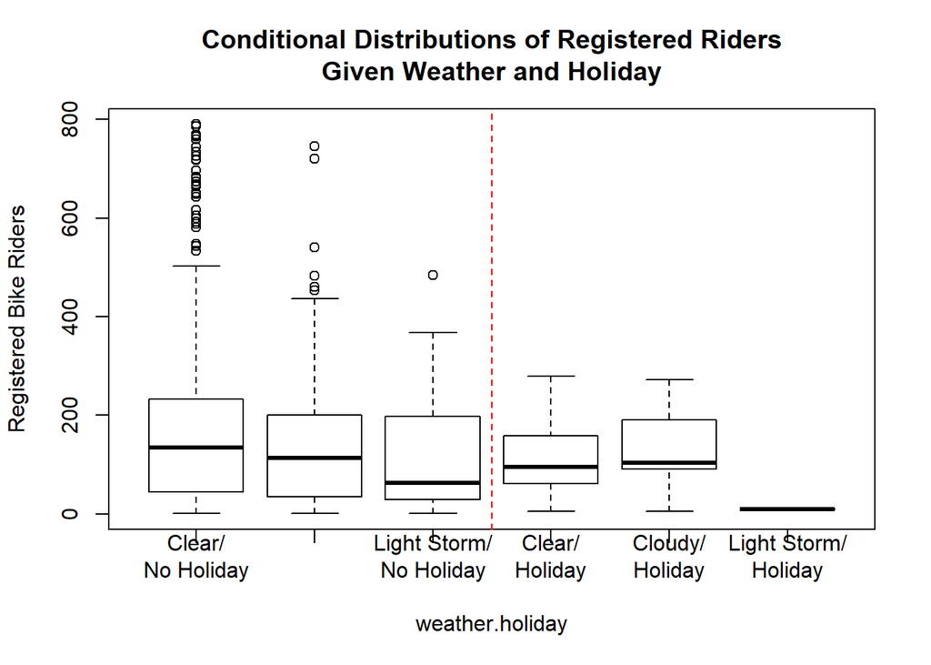

```r
#Model 2 Basic: Interactions
par(mfrow = c(1,1))

weather.holiday = rep(NA,nrow(bikes))
weather.holiday[Weather == 1 & Holiday == 0]<-1
weather.holiday[Weather == 2 & Holiday == 0]<-2
weather.holiday[Weather == 3 & Holiday == 0]<-3
weather.holiday[Weather == 1 & Holiday == 1]<-4
weather.holiday[Weather == 2 & Holiday == 1]<-5
weather.holiday[Weather == 3 & Holiday == 1]<-6
boxplot(Registered~weather.holiday,ylab="Registered Bike Riders",names=c("Clear/\nNo Holiday","Cloudy/\nNo Holiday","Light Storm/\nNo Holiday","Clear/\nHoliday","Cloudy/\nHoliday","Light Storm/\nHoliday"))
abline(v=3.5,lty=2,col=2)
title("Conditional Distributions of Registered Riders\nGiven Weather and Holiday")
```

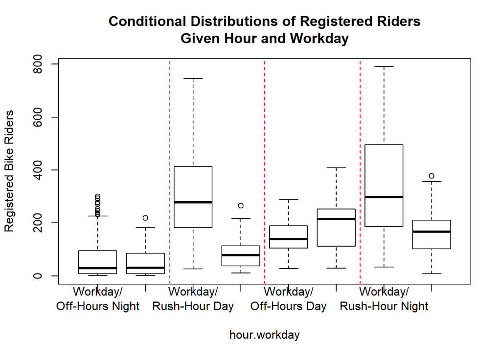

```r
hour.workday = rep(NA,nrow(bikes))
hour.workday[WorkDay == 1 & OffHours.Night == 1]<-1
hour.workday[WorkDay == 0 & OffHours.Night == 1]<-2
hour.workday[WorkDay == 1 & RushHour.Day == 1]<-3
hour.workday[WorkDay == 0 & RushHour.Day == 1]<-4
hour.workday[WorkDay == 1 & OffHours.Day == 1]<-5
hour.workday[WorkDay == 0 & OffHours.Day == 1]<-6
hour.workday[WorkDay == 1 & RushHour.Night == 1]<-7
hour.workday[WorkDay == 0 & RushHour.Night == 1]<-8
boxplot(Registered~hour.workday,ylab="Registered Bike Riders",names=c("Workday/\nOff-Hours Night","No Workday/\nOff-Hours Night","Workday/\nRush-Hour Day","No Workday/\nRush-Hour Day",
"Workday/\nOff-Hours Day","No Workday/\nOff-Hours Day","Workday/\nRush-Hour Night","No Workday/\nRush-Hour Night"))
abline(v=2.5,lty=2,col=2)
abline(v=4.5,lty=2,col=2)
abline(v=6.5,lty=2,col=2)
title("Conditional Distributions of Registered Riders\nGiven Hour and Workday")
```

```r
'hour.2 = Hour+1
plot(Hour,Registered,col = (WorkDay+1),xlab="Hours of the Day",ylab="Registered Bike Riders")
abline(lm(Registered[WorkDay == 0]~Hour[WorkDay == 0]),col=1,lwd=2)
abline(lm(Registered[WorkDay == 1]~Hour[WorkDay == 1]),col=2,lwd=2)

title("Hour vs. Registered Bike Rides \n Conditioned on Workday")
legend("topleft",c("Weekend","Workday"),col=c(1,2),lwd=2,pch=16)'
```

```
## [1] "hour.2 = Hour+1\nplot(Hour,Registered,col = (WorkDay+1),xlab=\"Hours of the Day\",ylab=\"Registered Bike Riders\")\nabline(lm(Registered[WorkDay == 0]~Hour[WorkDay == 0]),col=1,lwd=2)\nabline(lm(Registered[WorkDay == 1]~Hour[WorkDay == 1]),col=2,lwd=2)\n\ntitle(\"Hour vs. Registered Bike Rid…
```

```r
mod2.1 = lm(Registered~as.factor(Year)+Spring+Summer+Fall+RushHour.Day+OffHours.Day+RushHour.Night+as.factor(Holiday)+as.factor(WorkDay)+Weather+Temp+TempFeel+Humidity+Windspeed+Casual+Weather*as.factor(Holiday)+as.factor(WorkDay)*RushHour.Day+as.factor(WorkDay)*OffHours.Day+as.factor(WorkDay)*RushHour.Night)
summary(mod2.1)
```

```
##
## Call:
## lm(formula = Registered ~ as.factor(Year) + Spring + Summer +
##     Fall + RushHour.Day + OffHours.Day + RushHour.Night + as.factor(Holiday) +
##     as.factor(WorkDay) + Weather + Temp + TempFeel + Humidity +
##     Windspeed + Casual + Weather * as.factor(Holiday) + as.factor(WorkDay) *
##     RushHour.Day + as.factor(WorkDay) * OffHours.Day + as.factor(WorkDay) *
##     RushHour.Night)
##
## Residuals:
##     Min      1Q  Median      3Q     Max
## -243.21  -48.52   -2.88   40.42  357.99
##
## Coefficients:
##                                    Estimate Std. Error t value Pr(>|t|)
## (Intercept)                         -6.7376    21.5708  -0.312 0.754867
## as.factor(Year)2012                 70.7534     7.0068  10.098  < 2e-16
## Spring                               7.3973    11.7224   0.631 0.528221
## Summer                               9.9137    16.1400   0.614 0.539258
## Fall                                38.9575    11.6868   3.333 0.000903
## RushHour.Day                        -4.1698    19.7397  -0.211 0.832760
## OffHours.Day                        37.5758    19.3952   1.937 0.053100
## RushHour.Night                      55.8181    18.0917   3.085 0.002113
## as.factor(Holiday)1                -21.6056    47.3549  -0.456 0.648352
## as.factor(WorkDay)1                 13.3310    11.9133   1.119 0.263525
## Weather                            -22.7464     6.0162  -3.781 0.000170
## Temp                               -49.9960   148.2263  -0.337 0.735995
## TempFeel                           177.4955   161.2955   1.100 0.271519
## Humidity                           -38.6369    24.9371  -1.549 0.121742
## Windspeed                           -9.3248    30.8982  -0.302 0.762901
## Casual                               1.0209     0.1212   8.421  < 2e-16
## as.factor(Holiday)1:Weather         -5.0194    34.3719  -0.146 0.883938
## RushHour.Day:as.factor(WorkDay)1   258.5305    22.8923  11.293  < 2e-16
## OffHours.Day:as.factor(WorkDay)1    -2.7324    20.4426  -0.134 0.893709
## RushHour.Night:as.factor(WorkDay)1 186.8401    20.3997   9.159  < 2e-16
##
## (Intercept)
## as.factor(Year)2012                ***
## Spring
## Summer
## Fall                               ***
## RushHour.Day
## OffHours.Day                       .
## RushHour.Night                     **
## as.factor(Holiday)1
## as.factor(WorkDay)1
## Weather                            ***
## Temp
## TempFeel
## Humidity
## Windspeed
## Casual                             ***
## as.factor(Holiday)1:Weather
## RushHour.Day:as.factor(WorkDay)1   ***
## OffHours.Day:as.factor(WorkDay)1
## RushHour.Night:as.factor(WorkDay)1 ***
## ---
## Signif. codes:  0 '***' 0.001 '**' 0.01 '*' 0.05 '.' 0.1 ' ' 1
##
## Residual standard error: 89.86 on 703 degrees of freedom
## Multiple R-squared:  0.6931, Adjusted R-squared:  0.6848
## F-statistic: 83.57 on 19 and 703 DF,  p-value: < 2.2e-16
```

Essay notes: Interaction 1: Show graph of weather*holiday. No holiday side shows greater range. Clear*noholiday has a lot of outliers. Interaction 2: Hours definitely not parallel. We will use both interactions.

To-do’s: Understand boxplot Interactions. Edit Interaction graph 2.

Diagnostics: Normality/BoxCox

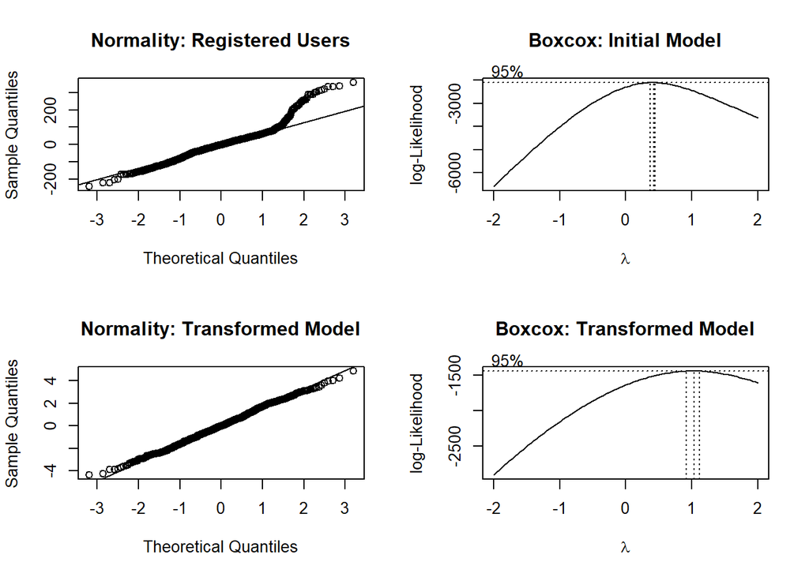

```r
#Model 3: Normality/Box Cox
par(mfrow=c(2,2))
qqnorm(mod2.1$res,main="Normality: Registered Users")
qqline(mod2.1$res)
boxcox1 = boxcox(mod2.1)
title("Boxcox: Initial Model")

registered2 = Registered^(.4)
mod3.1 = lm(registered2~as.factor(Year)+Spring+Summer+Fall+RushHour.Day+OffHours.Day+RushHour.Night+as.factor(Holiday)+as.factor(WorkDay)+Weather+Temp+TempFeel+Humidity+Windspeed+Casual+Weather*as.factor(Holiday)+as.factor(WorkDay)*RushHour.Day+as.factor(WorkDay)*OffHours.Day+as.factor(WorkDay)*RushHour.Night)
qqnorm(mod3.1$res,main="Normality: Transformed Model")
qqline(mod3.1$res)
boxcox2 = boxcox(mod3.1)
title("Boxcox: Transformed Model")
```

```r
summary(mod3.1)
```

```
##
## Call:
## lm(formula = registered2 ~ as.factor(Year) + Spring + Summer +
##     Fall + RushHour.Day + OffHours.Day + RushHour.Night + as.factor(Holiday) +
##     as.factor(WorkDay) + Weather + Temp + TempFeel + Humidity +
##     Windspeed + Casual + Weather * as.factor(Holiday) + as.factor(WorkDay) *
##     RushHour.Day + as.factor(WorkDay) * OffHours.Day + as.factor(WorkDay) *
##     RushHour.Night)
##
## Residuals:
##     Min      1Q  Median      3Q     Max
## -4.3714 -1.0964 -0.0224  1.1152  4.8703
##
## Coefficients:
##                                     Estimate Std. Error t value Pr(>|t|)
## (Intercept)                         3.125821   0.384724   8.125 2.01e-15
## as.factor(Year)2012                 1.045900   0.124969   8.369 3.12e-16
## Spring                              0.075408   0.209075   0.361 0.718451
## Summer                             -0.046947   0.287863  -0.163 0.870496
## Fall                                0.780977   0.208439   3.747 0.000194
## RushHour.Day                        0.655841   0.352067   1.863 0.062903
## OffHours.Day                        1.638788   0.345922   4.737 2.62e-06
## RushHour.Night                      1.994263   0.322674   6.180 1.08e-09
## as.factor(Holiday)1                 0.024174   0.844596   0.029 0.977174
## as.factor(WorkDay)1                 0.263202   0.212480   1.239 0.215865
## Weather                            -0.348150   0.107302  -3.245 0.001232
## Temp                                0.253339   2.643683   0.096 0.923685
## TempFeel                            2.887939   2.876778   1.004 0.315782
## Humidity                           -1.156064   0.444765  -2.599 0.009538
## Windspeed                          -0.251088   0.551083  -0.456 0.648800
## Casual                              0.018890   0.002162   8.736  < 2e-16
## as.factor(Holiday)1:Weather        -0.380154   0.613038  -0.620 0.535383
## RushHour.Day:as.factor(WorkDay)1    4.507216   0.408294  11.039  < 2e-16
## OffHours.Day:as.factor(WorkDay)1    0.062954   0.364602   0.173 0.862966
## RushHour.Night:as.factor(WorkDay)1  2.562191   0.363837   7.042 4.52e-12
##
## (Intercept)                        ***
## as.factor(Year)2012                ***
## Spring
## Summer
## Fall                               ***
## RushHour.Day                       .
## OffHours.Day                       ***
## RushHour.Night                     ***
## as.factor(Holiday)1
## as.factor(WorkDay)1
## Weather                            **
## Temp
## TempFeel
## Humidity                           **
## Windspeed
## Casual                             ***
## as.factor(Holiday)1:Weather
## RushHour.Day:as.factor(WorkDay)1   ***
## OffHours.Day:as.factor(WorkDay)1
## RushHour.Night:as.factor(WorkDay)1 ***
## ---
## Signif. codes:  0 '***' 0.001 '**' 0.01 '*' 0.05 '.' 0.1 ' ' 1
##
## Residual standard error: 1.603 on 703 degrees of freedom
## Multiple R-squared:  0.7315, Adjusted R-squared:  0.7243
## F-statistic: 100.8 on 19 and 703 DF,  p-value: < 2.2e-16
```

Outlier Analysis

```r
#Model 4: Outlier analysis
X<-cbind(1,as.factor(Year),Spring, Summer, Fall,RushHour.Day,OffHours.Day,RushHour.Night,as.factor(Holiday),as.factor(WorkDay),Weather,Temp,TempFeel,Humidity,Windspeed,Casual,Weather*ifelse(Holiday == 1,1,0),ifelse(WorkDay == 1,1,0)*RushHour.Day,ifelse(WorkDay == 1,1,0)*OffHours.Day,ifelse(WorkDay == 1,1,0)*RushHour.Night)

H<-X%*%solve(t(X)%*%X)%*%t(X)
n<-nrow(X);p<-ncol(X)
SSE<-sum(mod3.1$res^2)
MSE<-SSE/(n-p)
res<-mod3.1$res
del.res<-res*sqrt((n-p-1)/(SSE*(1-diag(H))-res^2))
alpha<-0.05
qt(1-alpha/(2*n),n-p-1)
```

```
## [1] 4.003152
```

```r
sort(del.res)[1:10]; sort(del.res)[(n-10):n]
```

```
##       302       531        95       576       238       681       626
## -2.791544 -2.780396 -2.552626 -2.437727 -2.430853 -2.342676 -2.315883
##       101        85       693
## -2.282884 -2.224701 -2.141473
```

```
##       12      120      350      114      679       99      351      382
## 2.071107 2.086024 2.102892 2.134545 2.175416 2.270759 2.418736 2.506809
##      680      357      452
## 2.550930 2.660028 3.095455
```

```r
mean.h<-p/n
which(diag(H)>2*mean.h)
```

```
##  [1]  14  95 126 135 136 159 183 213 228 283 284 302 308 314 321 355 371
## [18] 376 397 436 477 517 518 525 592 608 613 615 624 626 651 677 696 697
## [35] 717 721
```

```r
sort(diag(H))[(n-10):n]
```

```
##  [1] 0.08526629 0.08681407 0.08683105 0.09449527 0.09956254 0.12442498
##  [7] 0.13082709 0.13665537 0.14840871 0.16141427 0.47093102
```

```r
order(diag(H))[(n-10):n]
```

```
##  [1] 525 135 677 228 721 376 159 518 284 613 436
```